# Tidyverse

# Tidyverse

## Tidyverse

Ist eine Sammlung von Paketen von Hadley Wickham

- dplyr (Datenverarbeitung)
- ggplot2 (Grafiken)
- tidyr (Datenverarbeitung)
- stringr (Verarbeitung von Strings Regex)
- forcats (Factor-Variablen)
- purrr (Funktionales Programmieren)
- readr (Einlesen von Daten)

## 5 Verben

- `filter()` Zeilen auswählen mit einer Bedingung
- `select()` Spalten auswählen
- `arrange()` Sortieren
- `mutate()` Variablen hinzufügen
- `summarise()` Zeilen aggregieren

## Beispiel

Alle Star Wars Figuren

```r
starwars
```

```
## # A tibble: 87 x 13
##   name      height  mass hair_color skin_color eye_color birth_year gender
##   <chr>      <int> <dbl> <chr>      <chr>      <chr>          <dbl> <chr>
## 1 Luke Sky~    172  77.0 blond      fair       blue            19.0 male
## 2 C-3PO        167  75.0 <NA>       gold       yellow         112   <NA>
## 3 R2-D2         96  32.0 <NA>       white, bl~ red             33.0 <NA>
## 4 Darth Va~    202 136   none       white      yellow          41.9 male
## # ... with 83 more rows, and 5 more variables: homeworld <chr>,
## #   species <chr>, films <list>, vehicles <list>, starships <list>
```

# filter()

## filter()

`filter()` selektiert Zeilen die eine Bedingung erfüllen

```r
filter(starwars, species == "Human")
```

```
## # A tibble: 35 x 13
##   name      height  mass hair_color skin_color eye_color birth_year gender
##   <chr>      <int> <dbl> <chr>      <chr>      <chr>          <dbl> <chr>
## 1 Luke Sky~    172  77.0 blond      fair       blue            19.0 male
## 2 Darth Va~    202 136   none       white      yellow          41.9 male
## 3 Leia Org~    150  49.0 brown      light      brown           19.0 female
## 4 Owen Lars    178 120   brown, gr~ light      blue            52.0 male
## # ... with 31 more rows, and 5 more variables: homeworld <chr>,
## #   species <chr>, films <list>, vehicles <list>, starships <list>
```

## filter()

Mehrere Bedingungen können durch Komma getrennt werden. Wirkt wie ein `&`

```r
filter(starwars, species == "Human", gender == "female")
```

```
## # A tibble: 9 x 13
##   name      height  mass hair_color skin_color eye_color birth_year gender
##   <chr>      <int> <dbl> <chr>      <chr>      <chr>          <dbl> <chr>
## 1 Leia Org~    150  49.0 brown      light      brown           19.0 female
## 2 Beru Whi~    165  75.0 brown      light      blue            47.0 female
## 3 Mon Moth~    150  NA   auburn     fair       blue            48.0 female
## 4 Shmi Sky~    163  NA   black      fair       brown           72.0 female
## # ... with 5 more rows, and 5 more variables: homeworld <chr>,
## #   species <chr>, films <list>, vehicles <list>, starships <list>
```

## filter()

Komplexere Bedingungen sind natürlich auch möglich:

Vergleichs Operatoren:

`>, >=, <, <=, != , ==, %in%`

Boolsche Operatoren:

- `&` und
- `|` oder
- `xor(a,b)` entweder a oder b

## filter()

Achtung fehlende Werte!

```r
identical(
  filter(starwars, species != "Human"| is.na(species)),
  filter(starwars, species != "Human")
  )
```

```
## [1] FALSE
```

```r
map_int(list(
    human_na = filter(starwars, species != "Human"| is.na(species)),
    human = filter(starwars, species != "Human")),
  nrow)
```

```
## human_na    human
##       52       47
```

## filter()

Übung:

Alle Menschen größer als 1.90m

```r
filter(starwars,
       height > 190 & species == "Human")
```

Blaue oder gelbe Augen und nicht menschlich

```r
filter(starwars,
          eye_color %in% c("blue", "yellow"),
          species != "Human")
```

# select()

## select()

- `rename()` behält alle Spalten und benennt um `rename(df, new = old)`
- `select()` selektiert Spalten über Namen oder Positionen

```r
# select(starwars, 1, 9)
select(starwars, name, homeworld)
```

```
## # A tibble: 87 x 2
##   name           homeworld
##   <chr>          <chr>
## 1 Luke Skywalker Tatooine
## 2 C-3PO          Tatooine
## 3 R2-D2          Naboo
## 4 Darth Vader    Tatooine
## # ... with 83 more rows
```

## select()

Auswahl ist auch über mehrere Variablen möglich

```r
select(starwars, name:mass)
```

```
## # A tibble: 87 x 3
##   name           height  mass
##   <chr>           <int> <dbl>
## 1 Luke Skywalker    172  77.0
## 2 C-3PO             167  75.0
## 3 R2-D2              96  32.0
## 4 Darth Vader       202 136
## # ... with 83 more rows
```

## select()

Entfernen von Spalten mit `-`

```r
select(starwars, -name)
```

```
## # A tibble: 87 x 12
##   height  mass hair_color skin_color eye_color birth_year gender homeworld
##    <int> <dbl> <chr>      <chr>      <chr>          <dbl> <chr>  <chr>
## 1    172  77.0 blond      fair       blue            19.0 male   Tatooine
## 2    167  75.0 <NA>       gold       yellow         112   <NA>   Tatooine
## 3     96  32.0 <NA>       white, bl~ red             33.0 <NA>   Naboo
## 4    202 136   none       white      yellow          41.9 male   Tatooine
## # ... with 83 more rows, and 4 more variables: species <chr>,
## #   films <list>, vehicles <list>, starships <list>
```

## select()

Selection helper

- `starts_with()`: Startet mit einem Prefix
- `ends_with()`: Endet mit einem Suffix
- `contains()`: Enthält einen String
- `matches()`: Matched eine RegEx
- `num_range("x", 1:3)`: x1, x2, x3.
- `one_of()`: Variablen in einem character Vector
- `everything()`: Alle Variablen.

## select()

```r
select(starwars, name, ends_with("color"))
```

```
## # A tibble: 87 x 4
##   name           hair_color skin_color  eye_color
##   <chr>          <chr>      <chr>       <chr>
## 1 Luke Skywalker blond      fair        blue
## 2 C-3PO          <NA>       gold        yellow
## 3 R2-D2          <NA>       white, blue red
## 4 Darth Vader    none       white       yellow
## # ... with 83 more rows
```

## select()

Übung:

Stelle `homeworld` an den Anfang

```r
select(starwars, homeworld, everything())
```

Benne `gender` in `sex` um

```r
rename(starwars, sex = gender)
```

# mutate()

## mutate()

- `mutate()` erzeugt neue Variablen
- `transmute()` erzeugt Variablen und behält nur die neuen Variablen

```r
starwars_short <- select(starwars, name:mass)
mutate(starwars_short, bmi = mass/(height/100)^2)
```

```
## # A tibble: 87 x 4
##   name           height  mass   bmi
##   <chr>           <int> <dbl> <dbl>
## 1 Luke Skywalker    172  77.0  26.0
## 2 C-3PO             167  75.0  26.9
## 3 R2-D2              96  32.0  34.7
## 4 Darth Vader       202 136    33.3
## # ... with 83 more rows
```

## mutate()

Erzeugte Variablen können bereits referenziert werden

```r
mutate(starwars_short,
       bmi = mass/(height/100)^2,
       adipositas = bmi >= 30)
```

```
## # A tibble: 87 x 5
##   name           height  mass   bmi adipositas
##   <chr>           <int> <dbl> <dbl> <lgl>
## 1 Luke Skywalker    172  77.0  26.0 F
## 2 C-3PO             167  75.0  26.9 F
## 3 R2-D2              96  32.0  34.7 T
## 4 Darth Vader       202 136    33.3 T
## # ... with 83 more rows
```

## mutate()

- Arithmetische Operatoren: `+, -, *, /, ^`
- Modulus Opratoren: `%/%, %%`
- Logarithmen: `log(), log2(), log10()`
- Verschiebung: `lead(), lag()`
- Vergleich von Spalten: `pmax()`, `pmin()`
- Kumulative Funktionen: `cumsum()`, `cummean()`, `cummax()`, mehr in `RcppRoll`
- Logische Operatoren
- Rang-Funktionen: `min_rank()`, `cume_dist()`, `percent_rank()`, …
- Factor Funktionen: `cut()`, `recode()`
- `if_else()`, `coalesce()`, `case_when()`, `na_if()`

## mutate()

Beispiel

```r
mutate(starwars_short,
       bmi = mass/(height/100)^2,
       bmi_category =
         cut(bmi, breaks = c(0, 18.5, 25, 30,Inf),
              labels = c("underweight", "normal",
                         "overweight", "obese"),
              ordered_result = TRUE),
       bmi_rank = min_rank(bmi))
```

```
## # A tibble: 87 x 6
##   name           height  mass   bmi bmi_category bmi_rank
##   <chr>           <int> <dbl> <dbl> <ord>           <int>
## 1 Luke Skywalker    172  77.0  26.0 overweight         42
## 2 C-3PO             167  75.0  26.9 overweight         46
## 3 R2-D2              96  32.0  34.7 obese              54
## 4 Darth Vader       202 136    33.3 obese              50
## # ... with 83 more rows
```

# arrange()

## arrange()

- Sortiert den Datensatz nach einer Variable (aufsteigend)
- `desc()` ändert die Richtung zu absteigend
- Weitere Variablen lösen Bindungen auf
- Fehlende Werte werden ans Ende sortiert

```r
arrange(starwars, desc(hair_color), mass)
```

```
## # A tibble: 87 x 13
##   name      height  mass hair_color skin_color eye_color birth_year gender
##   <chr>      <int> <dbl> <chr>      <chr>      <chr>          <dbl> <chr>
## 1 Yoda          66  17.0 white      green      brown          896   male
## 2 Dooku        193  80.0 white      fair       brown          102   male
## 3 Ki-Adi-M~    198  82.0 white      pale       yellow          92.0 male
## 4 Jocasta ~    167  NA   white      fair       blue            NA   female
## # ... with 83 more rows, and 5 more variables: homeworld <chr>,
## #   species <chr>, films <list>, vehicles <list>, starships <list>
```

# summarize()

## summarize()

Fasst einen Datensatz zu einer Zeile zusammen

```r
summarize(starwars, mean_height = mean(height, na.rm =TRUE))
```

```
## # A tibble: 1 x 1
##   mean_height
##         <dbl>
## 1         174
```

## summarize()

- Aggregation: `sum()`
- Lage: `mean()`, `weighted.mean()`, `median()`, …
- Verteilung: `var()`, `sd()`, `IQR()`, `mad()`
- Rang: `min()`, `max()`, `nth()`
- Anzahl: `n()`, `n_distinct()`
- Summe mit Bedingung: `sum(!is.na())`, `sum(x > 5)`

## group_by()

- `group_by()` ändert die Analyseeinheit zu Guppen
- `ungroup()` hebt die Gruppierung wieder auf

```r
starwars_group <- group_by(starwars, gender)
summarize(starwars_group,
          mean_height = mean(height, na.rm =TRUE))
```

```
## # A tibble: 5 x 2
##   gender        mean_height
##   <chr>               <dbl>
## 1 female                165
## 2 hermaphrodite         175
## 3 male                  179
## 4 none                  200
## 5 <NA>                  120
```

# Die Pipe `%>%`

## Die Pipe `%>%`

Längere Befehlsfolgen können unübersichtlich werden.

Entweder viele Datensätze nutzen

```r
starwars_1 <- filter(starwars, species == "Human")
starwars_2 <- group_by(starwars_1, gender)
summarise(starwars_2, n = n())
```

oder Funktionen verschachteln

```r
summarise(
  group_by(
    filter(starwars, species == "Human"),
  gender),
n = n())
```

## Die Pipe `%>%`

Das Konzept der Pipe stammt aus der Unix-Welt.

Das Objekt links wird das erste Argument der Funktion

- `f(x, y)` wird zu `x %>% f(y)`
- `g(f(x), y)` wird zu `f(x) %>% g(y)`
- `f(x, y ,z)` ist gleich `y %>% f(x, ., z)`

```r
filter(starwars, species == "Human") %>%
  group_by(gender) %>%
  summarise(n= n())
```

```
## # A tibble: 2 x 2
##   gender     n
##   <chr>  <int>
## 1 female     9
## 2 male      26
```

## Die Pipe `%>%`

Falls der Datesatz nicht das erste Argument ist, kann man mit `.` explizit auf den Datensatz verweisen

```r
starwars %>%
  filter(
    species == "Human",
    homeworld %in% c("Alderaan", "Tatooine", "Naboo")
  ) %>%
  xtabs(~ eye_color + homeworld, data = .)
```

```
##          homeworld
## eye_color Alderaan Naboo Tatooine
##    blue          0     0        5
##    brown         3     4        2
##    yellow        0     1        1
```

## Übung

Durchschnitt und Median des BMI pro Spezies und Geschlecht, sortiert absteigend nach der Anzahl.

```r
starwars %>%
  mutate(bmi = mass / (height / 100)^2) %>%
  group_by(species, gender) %>%
  summarise(mean = mean(bmi, na.rm = TRUE),
          med = median(bmi, na.rm = TRUE),
          n = sum(!is.na(bmi))) %>%
  arrange(desc(n))
```

```
## # A tibble: 43 x 5
## # Groups:   species [38]
##   species gender  mean   med     n
##   <chr>   <chr>  <dbl> <dbl> <int>
## 1 Human   male    26.0  24.8    19
## 2 Droid   <NA>    31.9  34.0     3
## 3 Human   female  22.0  21.8     3
## 4 Gungan  male    16.8  16.8     2
## # ... with 39 more rows
```

## group_by()

`group_by()` funktioniert auch mit `mutate()` und `filter()`

```r
starwars %>%
  select(name, homeworld, mass, species) %>%
  group_by(homeworld) %>%
  mutate(avg_mass = mean(mass, na.rm = TRUE)) %>%
  filter(sum(!is.na(mass)) > 3)
```

```
## # A tibble: 21 x 5
## # Groups:   homeworld [2]
##   name           homeworld  mass species avg_mass
##   <chr>          <chr>     <dbl> <chr>      <dbl>
## 1 Luke Skywalker Tatooine   77.0 Human       85.4
## 2 C-3PO          Tatooine   75.0 Droid       85.4
## 3 R2-D2          Naboo      32.0 Droid       64.2
## 4 Darth Vader    Tatooine  136   Human       85.4
## # ... with 17 more rows
```

# Verschiedenes

## Scoped

Varianten der `summarise()`, `mutate()` Funktionen

- `_if` Variablen die eine Bedingung erfüllen
- `_all` alle nicht gruppierenden Variablen
- `_at` alle Variablen selektiert durch `select_helpers`

```r
starwars %>% mutate_at(vars(ends_with("color")), as.factor)
```

```r
starwars %>% summarise_if(is.numeric, mean, na.rm = TRUE)
```

```
## # A tibble: 1 x 3
##   height  mass birth_year
##    <dbl> <dbl>      <dbl>
## 1    174  97.3       87.6
```

## Scoped

Für `filter()`, `select` und `group_by()` exisiteren auch `_all`, `_if`, `_at` Versionen

Alle Zeilen die keine fehlenden Werte enthalten

```r
starwars %>% filter_all(all_vars(!is.na(.)))
```

```
## # A tibble: 29 x 13
##   name      height  mass hair_color skin_color eye_color birth_year gender
##   <chr>      <int> <dbl> <chr>      <chr>      <chr>          <dbl> <chr>
## 1 Luke Sky~    172  77.0 blond      fair       blue            19.0 male
## 2 Darth Va~    202 136   none       white      yellow          41.9 male
## 3 Leia Org~    150  49.0 brown      light      brown           19.0 female
## 4 Owen Lars    178 120   brown, gr~ light      blue            52.0 male
## # ... with 25 more rows, and 5 more variables: homeworld <chr>,
## #   species <chr>, films <list>, vehicles <list>, starships <list>
```

## Sonstiges

- `slice(starwars, 1:5)` selektiert Zeilen nach Position
- `sample_n()` oder `sample_frac()` ziehen Zufallsauswahl
- `top_n()` Top `n` pro Gruppe (gewichtet)
- `pull(.data, var)` äquivalent `.data[[var]]`
- `distinct()` doppelte Einträge entfernen

## List columns

Tibbles können Listen, Objekte oder Tibbles als Wert enthalten

```r
starwars %>%
  filter(name == "R2-D2") %>%
  select(films) %>%
  pull()
```

```
## [[1]]
## [1] "Attack of the Clones"    "The Phantom Menace"
## [3] "Revenge of the Sith"     "Return of the Jedi"
## [5] "The Empire Strikes Back" "A New Hope"
## [7] "The Force Awakens"
```

## Do

- `do()` führt Funktionen auf dem (gruppiertem) Tibble aus und schreibt das Ergebnis in eine Zelle
- `group_by()`- `do()` wird vermutlich bald durch `tidyr::nest()` - `purrr::map` ersetzt.

```r
starwars %>% group_by(species) %>% filter(n()>3) %>%
  do(mod = lm(mass ~height, data = .)) %>%
  mutate(r_squared = summary(mod)$r.squared,
         n = length(resid(mod)))
```

```
## Source: local data frame [3 x 4]
## Groups: <by row>
##
## # A tibble: 3 x 4
##   species mod      r_squared     n
##   <chr>   <list>       <dbl> <int>
## 1 Droid   <S3: lm>     0.921     4
## 2 Human   <S3: lm>     0.425    22
## 3 <NA>    <S3: lm>     0         1
```

# Relational Data

## Relational Data

- Relationen sind Verbindungen zwischen genau zwei Tabellen
- Primaray Key: Eindeutig für eine Beobachtung in der eigenen Tabelle
- Foreign Key: Eindeutige Identifizierung in einer anderen Tabelle

## Relational Data

- Mutating Join: fügen Spalten hinzu
- Filtering Join: filtert Beobachtungen
- Mengen Operationen

## Inner Join

`inner_join(x, y)`

Gibt alle Beobachtungen zurück die sowohl in `x`, als auch in `y` vorkommen

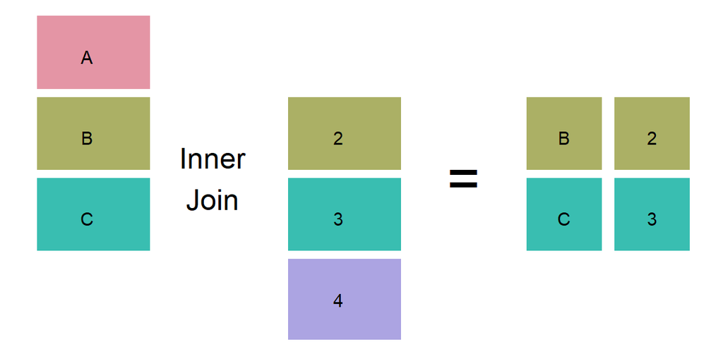

## Left Join

- `left_join(x, y)` Gibt alle Beobachtungen zurück die in `x` enthalten sind ergänzt um die Informatioen aus `y`
- `right_join(x,y)` = `left_join(y,x)`

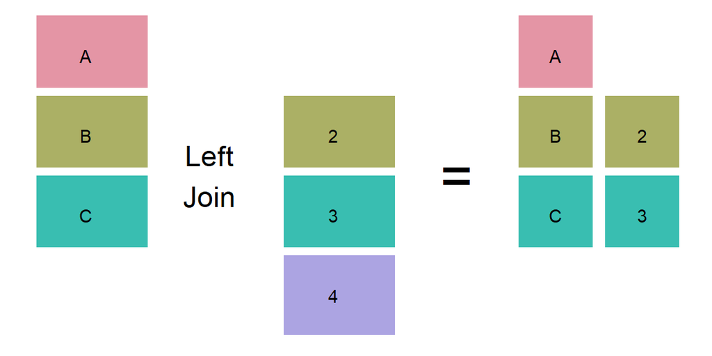

## Full Join

`full_join(x, y)`

Gibt alle Beobachtungen aus `x` und `y` zurück

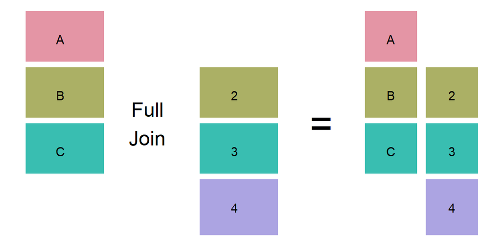

## Join

Doppelte Schlüssel

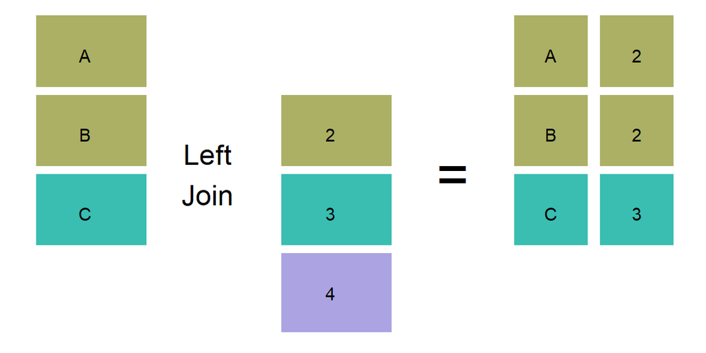

## Semi Join

`semi_join(x,y)` behält alle Fälle aus `x` die eine Entsprechung in `y` haben.

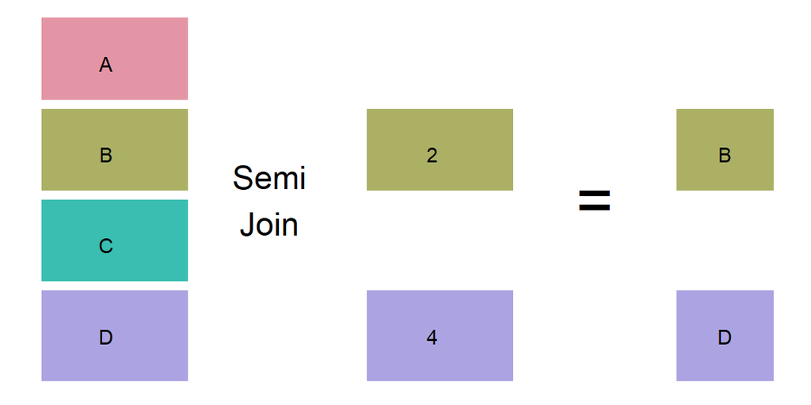

## Anti Join

`anti_join` entfernt alle Beobachtungen aus `x` die eine Entsprechung in `y` haben

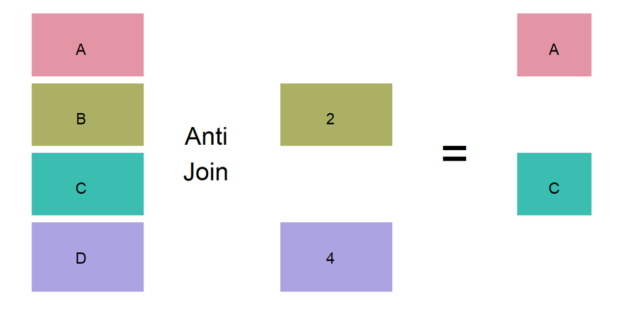

## Beispiele

```r
(planets <- tribble(
  ~homeworld, ~type,
  "Tatooine",  "Desert",
  "Naboo",     "Terrestrial",
  "Alderaan",  "Terrestrial",
  "Coruscant", "Ecumenopolis",
  "Kashyyyk",  "Jungle"
))
```

```
## # A tibble: 5 x 2
##   homeworld type
##   <chr>     <chr>
## 1 Tatooine  Desert
## 2 Naboo     Terrestrial
## 3 Alderaan  Terrestrial
## 4 Coruscant Ecumenopolis
## 5 Kashyyyk  Jungle
```

## Join

- `*_join()` macht automatisch einen natürlichen Join über alle Variablen mit gleichen Namen
- mit `by` können explizit Variablen angegeben werden

```r
left_join(starwars, planets) %>%
  # left_join(starwars, planets, by = "homeworld" ) %>%
  select(name, homeworld, type)
```

```
## # A tibble: 87 x 3
##   name           homeworld type
##   <chr>          <chr>     <chr>
## 1 Luke Skywalker Tatooine  Desert
## 2 C-3PO          Tatooine  Desert
## 3 R2-D2          Naboo     Terrestrial
## 4 Darth Vader    Tatooine  Desert
## # ... with 83 more rows
```

## Join

- Schlüsselvariablen mit unterschiedlichen Namen können auch explizt angegeben werden
- `by = c("a" = "b")` joined `x.a` mit `y.b`

```r
planets %>%
  rename(planet_name = homeworld) %>%
  right_join(starwars, by = c("planet_name" = "homeworld")) %>%
  select(name, planet_name, type)
```

```
## # A tibble: 87 x 3
##   name           planet_name type
##   <chr>          <chr>       <chr>
## 1 Luke Skywalker Tatooine    Desert
## 2 C-3PO          Tatooine    Desert
## 3 R2-D2          Naboo       Terrestrial
## 4 Darth Vader    Tatooine    Desert
## # ... with 83 more rows
```

## Join

- Falls in Datensätzen Variablen mit gleichen Namen vorkommen, werden sie automatisch umbenannt
- Kann mit der Option `suffix` angepasst werden

```r
planets %>%
  rename(name = type) %>%
  right_join(starwars,
             by = "homeworld",
             suffix = c(".x", ".y")) %>%
  select(homeworld, name.x, name.y)
```

```
## # A tibble: 87 x 3
##   homeworld name.x      name.y
##   <chr>     <chr>       <chr>
## 1 Tatooine  Desert      Luke Skywalker
## 2 Tatooine  Desert      C-3PO
## 3 Naboo     Terrestrial R2-D2
## 4 Tatooine  Desert      Darth Vader
## # ... with 83 more rows
```

## Übung

Nur erdähnliche Planeten

```r
left_join(starwars, planets) %>%
  filter(type == "Terrestrial") %>%
  dim()
```

```
## [1] 14 14
```

```r
planets %>%
  filter(type == "Terrestrial") %>%
  semi_join(starwars, .) %>%
  dim()
```

```
## [1] 14 13
```

## Mengen

- union(x, y): entspricht `bind_rows` oder SQL `UNION`
- union_all(x, y): wie `union` ohne doppelte Werte
- intersect(x, y): in `x` und `y` vorhanden
- setdiff(x, y): in `x` enthalten und nicht in `y`

```r
setdiff(starwars[1:10,1:3], starwars[6:15,1:3])
```

```
## # A tibble: 5 x 3
##   name           height  mass
##   <chr>           <int> <dbl>
## 1 Luke Skywalker    172  77.0
## 2 C-3PO             167  75.0
## 3 R2-D2              96  32.0
## 4 Darth Vader       202 136
## 5 Leia Organa       150  49.0
```

# Databases

## Databases

Man kann mit `dplyr` direkt auf Datenbanken zugreifen.

Database Funktionen sind nach `dbplyr` ausgelagert.

```r
library(RSQLite)
con <- DBI::dbConnect(RSQLite::SQLite(), ":memory:")
copy_to(con, select_if(starwars, ~!is_list(.)), name = "starwars")
copy_to(con, planets)
```

## Databases

Mit `tbl` wird eine Verknüpfung zur Datenbank erstellt

Die Ausführung ist *lazy*. Zeilen müssen explizit angefordert werden

```r
planets_tbl<- tbl(con, "planets")
starwars_tbl <- tbl(con, "starwars")
starwars_tbl
```

```
## # Source:   table<starwars> [?? x 10]
## # Database: sqlite 3.19.3 [:memory:]
##   name      height  mass hair_color skin_color eye_color birth_year gender
##   <chr>      <int> <dbl> <chr>      <chr>      <chr>          <dbl> <chr>
## 1 Luke Sky~    172  77.0 blond      fair       blue            19.0 male
## 2 C-3PO        167  75.0 <NA>       gold       yellow         112   <NA>
## 3 R2-D2         96  32.0 <NA>       white, bl~ red             33.0 <NA>
## 4 Darth Va~    202 136   none       white      yellow          41.9 male
## # ... with more rows, and 2 more variables: homeworld <chr>, species <chr>
```

## Databases

`dplyr` Befehle werden auf der Datenbank ausgeführt.

Mit `collect()` werden alle Zeilen geholt.

```r
starwars_tbl %>% left_join(planets_tbl) %>%
  filter(type == "Desert") %>%
  select(name:mass, homeworld)
```

```
## # Source:   lazy query [?? x 4]
## # Database: sqlite 3.19.3 [:memory:]
##   name           height  mass homeworld
##   <chr>           <int> <dbl> <chr>
## 1 Luke Skywalker    172  77.0 Tatooine
## 2 C-3PO             167  75.0 Tatooine
## 3 Darth Vader       202 136   Tatooine
## 4 Owen Lars         178 120   Tatooine
## # ... with more rows
```

## Databases

`dplyr` Befehle werden in SQL umgewandelt.

`show_query()` zeigt den generierten SQL-Code

```r
starwars_tbl %>% left_join(planets_tbl) %>%
  filter(type == "Desert") %>%
  show_query()
```

```
## <SQL>
## SELECT *
## FROM (SELECT `TBL_LEFT`.`name` AS `name`, `TBL_LEFT`.`height` AS `height`, `TBL_LEFT`.`mass` AS `mass`, `TBL_LEFT`.`hair_color` AS `hair_color`, `TBL_LEFT`.`skin_color` AS `skin_color`, `TBL_LEFT`.`eye_color` AS `eye_color`, `TBL_LEFT`.`birth_year` AS `birth_year`, `TBL_LEFT`.`gender` AS `gender`…
##   FROM `starwars` AS `TBL_LEFT`
##   LEFT JOIN `planets` AS `TBL_RIGHT`
##   ON (`TBL_LEFT`.`homeworld` = `TBL_RIGHT`.`homeworld`)
## )
## WHERE (`type` = 'Desert')
```

# tidyr

## Tidy Data

[Tidy data](http://vita.had.co.nz/papers/tidy-data.html)

Daten in einer vernünftigen Struktur (3. Normalform)

- Jede Variable hat eine eigene Spalte
- Jede Beobachtung hat eine eigen Zeile
- eine Tabelle für jede Art von Variable

## Messy Data

| person | treatment_a | treatment_b |
| --- | --- | --- |
| John Smith | -99999 | 2 |
| Jane Doe | 16 | 11 |
| Mary Johnson | 3 | 1 |

Transponiert

| treatment | Jane Doe | John Smith | Mary Johnson |
| --- | --- | --- | --- |
| treatment_a | 16 | -99999 | 3 |
| treatment_b | 11 | 2 | 1 |

## Tidy Data

Variablen

- `person` mit drei möglichen Werten
- `result` mit 5 oder 6 Ausprägungen
- `treatment` mit 2 Ausprägungen

## Tidy data

| person | treatment | result |
| --- | --- | --- |
| John Smith | a | NA |
| Jane Doe | a | 16 |
| Mary Johnson | a | 3 |
| John Smith | b | 2 |
| Jane Doe | b | 11 |
| Mary Johnson | b | 1 |

## Gather

`gather()` fasst mehrere Spalten in Key-Value-Paare zusammen.

```r
# gather(messy, key = treatment, value = result, treatment_a, treatment_b)
nearly_tidy <-
  gather(messy, key = treatment, value = result, -person)
nearly_tidy
```

```
## # A tibble: 6 x 3
##   person       treatment      result
##   <chr>        <chr>           <dbl>
## 1 John Smith   treatment_a -99999
## 2 Jane Doe     treatment_a     16.0
## 3 Mary Johnson treatment_a      3.00
## 4 John Smith   treatment_b      2.00
## 5 Jane Doe     treatment_b     11.0
## 6 Mary Johnson treatment_b      1.00
```

## Spread

`spread()` wandelt Key-Value Paare in eigene Spalten um

```r
# spread(nearly_tidy, treatment, result)
spread(nearly_tidy, key = person, value = result)
```

```
## # A tibble: 2 x 4
##   treatment   `Jane Doe` `John Smith` `Mary Johnson`
##   <chr>            <dbl>        <dbl>          <dbl>
## 1 treatment_a       16.0    -99999              3.00
## 2 treatment_b       11.0         2.00           1.00
```

## Tidy Data

```r
tidy <- gather(messy, key = treatment, value = result, -person) %>%
  mutate(result = na_if(result, -99999),
         treatment = str_sub(treatment, -1))
tidy
```

```
## # A tibble: 6 x 3
##   person       treatment result
##   <chr>        <chr>      <dbl>
## 1 John Smith   a          NA
## 2 Jane Doe     a          16.0
## 3 Mary Johnson a           3.00
## 4 John Smith   b           2.00
## 5 Jane Doe     b          11.0
## 6 Mary Johnson b           1.00
```

## Tidy Data

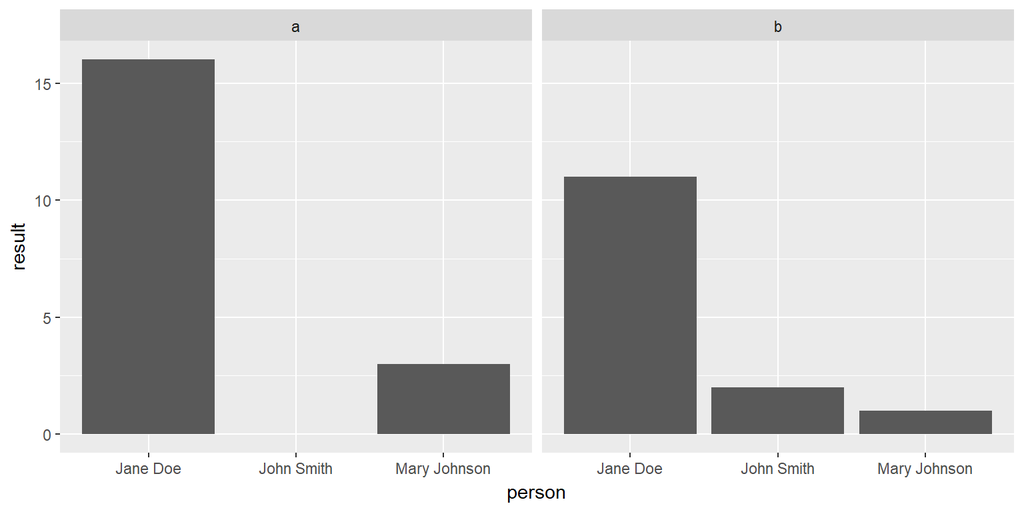

```r
tidy %>%
  ggplot(aes(x = person, y =result))+
  geom_col()+
  facet_wrap(~treatment)
```

# Links

## Links

- [R for Data Science](http://r4ds.had.co.nz/)
- [tidyverse.org](https://www.tidyverse.org/)
- [Cheat Sheets](https://www.rstudio.com/resources/cheatsheets/)
- [Stackoverflow](https://stackoverflow.com/questions/tagged/r)